# Model Selection & Model Performance

## 2.3 Model 3

This model will now use 3 convolutional layers and introduce more dense layers into the model. As I have a general overview of what parameters produce what results I do not have to do as many tests as before.

### 2.3.1 Create the Model

```python
model = Sequential()
```

### 2.3.2 Add the Convolutional Layers

```python
model.add(Conv2D(64, (3,3), input_shape = X.shape[1:]))
model.add(Activation("relu"))
model.add(MaxPooling2D(pool_size=(2,2)))

model.add(Conv2D(128, (3,3)))
model.add(Activation("relu"))
model.add(MaxPooling2D(pool_size=(2,2)))

model.add(Conv2D(256, (3,3)))
model.add(Activation("relu"))
model.add(MaxPooling2D(pool_size=(2,2)))
```

### 2.3.3 Add the Dense Layers

```python
model.add(Flatten())
model.add(Dense(64))
model.add(Activation("relu"))

model.add(Dense(32))
model.add(Activation("relu"))

model.add(Dense(1))
model.add(Activation("sigmoid"))
```

### 2.3.4 Compile the Model

```python
model.compile(loss="binary_crossentropy",
             optimizer="Adam",
             metrics=['accuracy'])
```

### 2.3.5 Fit the Model

Results batch = 16 features = 16,32,64 dense = 32 val_acc = 77% val_loss = 0.8442  
Results batch = 16 features = 32,64,128 dense = 32 val_acc = 77% val_loss = 0.9621  
Results batch = 16 features = 16,32,64 dense = 64 val_acc = 81% val_loss = 0.6397  
Results batch = 16 features = 32,64,128 dense = 64 val_acc = 79% val_loss = 1.0149  
Results batch = 16 features = 16,32,64 dense = 64,64 val_acc = 82% val_loss = 1.0473  
Results batch = 16 features = 16,32,64 dense = 64,64,64 val_acc = 80% val_loss = 0.9187

```python
model3_03 = model.fit(X, y, batch_size=16, epochs=50, validation_split=0.33)
```

```
Train on 334 samples, validate on 166 samples
```

### 2.3.6 Plot the Models Loss

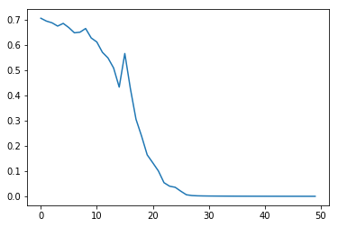

```python
plt.plot(model3_02.history["loss"])
plt.show()
```

### 2.3.7 Further visualizations

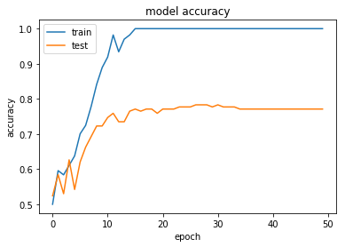

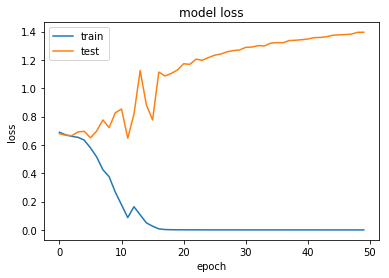

```python
plt.plot(model3_03.history['acc'])
plt.plot(model3_03.history['val_acc'])
plt.title('model accuracy')
plt.ylabel('accuracy')
plt.xlabel('epoch')
plt.legend(['train', 'test'], loc='upper left')
plt.show()

plt.plot(model3_03.history['loss'])
plt.plot(model3_03.history['val_loss'])
plt.title('model loss')
plt.ylabel('loss')
plt.xlabel('epoch')
plt.legend(['train', 'test'], loc='upper left')
plt.show()
```

### 2.3.8 Sub-plot the Models Loss

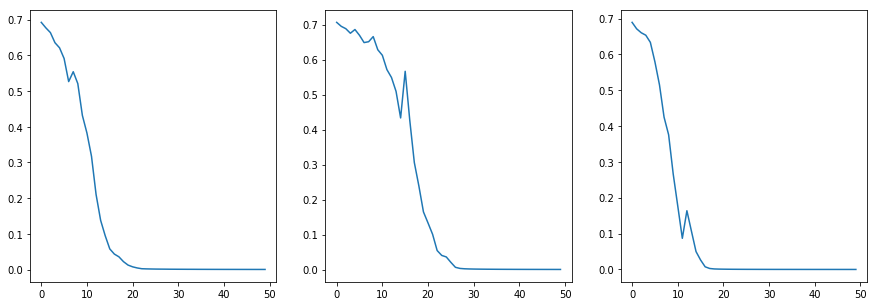

```python
fig = plt.figure(figsize=(15,5))

plt.subplot(1, 3, 1)
plt.plot(model3_01.history['loss'])

plt.subplot(1, 3, 2)
plt.plot(model3_02.history['loss'])

plt.subplot(1, 3, 3)
plt.plot(model3_03.history['loss'])
```

## 2.4 Model 4

### 2.4.1 Create the Model

```python
model = Sequential()
```

### 2.4.2 Add the Convolutional Layers

```python
model.add(Conv2D(16, (3,3), input_shape = X.shape[1:]))
model.add(Activation("relu"))
model.add(MaxPooling2D(pool_size=(2,2)))

model.add(Conv2D(32, (3,3)))
model.add(Activation("relu"))
model.add(MaxPooling2D(pool_size=(2,2)))

model.add(Conv2D(64, (3,3)))
model.add(Activation("relu"))
model.add(MaxPooling2D(pool_size=(2,2)))

model.add(Conv2D(128, (3,3)))
model.add(Activation("relu"))
model.add(MaxPooling2D(pool_size=(2,2)))
```

### 2.4.3 Add the Dense Layers

```python
model.add(Flatten())

model.add(Dense(64))
model.add(Activation("relu"))

model.add(Dense(32))
model.add(Activation("relu"))

model.add(Dense(1))
model.add(Activation("sigmoid"))
```

### 2.4.4 Compile the Model

```python
model.compile(loss="binary_crossentropy",
             optimizer="Adam",
             metrics=['accuracy'])
```

### 2.4.5 Fit the Model

```python
model4_01 = model.fit(X, y, batch_size=16, epochs=50, validation_split=0.33)
```

```
Train on 334 samples, validate on 166 samples
```

### 2.4.6 Plot the Models Loss

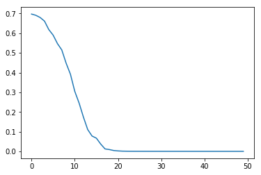

```python
plt.plot(model4_02.history["loss"])
plt.show()
```

### 2.4.7 Further visualizations

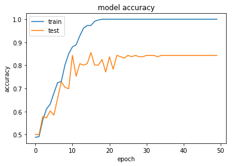

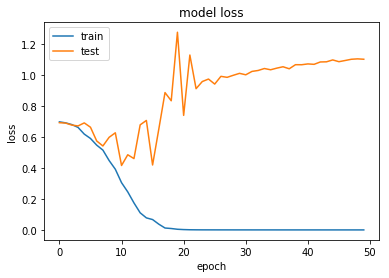

```python
plt.plot(model4_02.history['acc'])
plt.plot(model4_02.history['val_acc'])
plt.title('model accuracy')
plt.ylabel('accuracy')
plt.xlabel('epoch')
plt.legend(['train', 'test'], loc='upper left')
plt.show()

plt.plot(model4_02.history['loss'])
plt.plot(model4_02.history['val_loss'])
plt.title('model loss')
plt.ylabel('loss')
plt.xlabel('epoch')
plt.legend(['train', 'test'], loc='upper left')
plt.show()
```

### 2.4.8 Sub-plot the Results

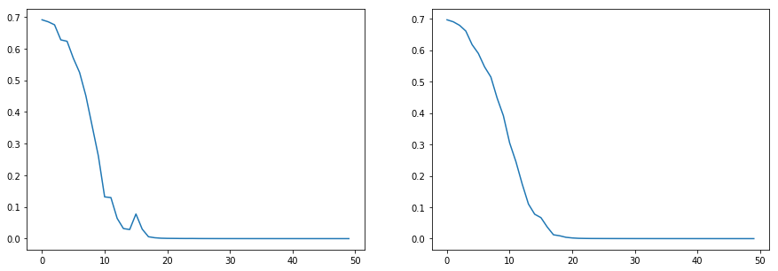

```python
fig = plt.figure(figsize=(15,5))

plt.subplot(1, 2, 1)
plt.plot(model4_01.history['loss'])

plt.subplot(1, 2, 2)
plt.plot(model4_02.history['loss'])
```